# PEC1 Análisis de Datos Ómicos

Rita Ortega Vallbona

3 de mayo, 2020

# 1 Abstract

Caveolin-1 (CAV1) es un gen regulador del metabolismo y la acumulación de lípidos. En el presente estudio se pretende evaluar el efecto de suprimir este gen en condiciones normales y en el desarrollo de la enfermedad de hígado graso no alcohólico (NAFLD), provocada por la dieta en ratones macho y hembra. En el estudio no se detectan diferencias de expresión de genes provocadas por la supresión del gen pero sí hay diferencias entre géneros en animales sanos y en animales con NAFLD provocado por dieta.

# 2 Objetivos

El presente estudio consiste en hacer un análisis de microarrays que consiste en 24 muestras divididas en 8 grupos donde se aplican 3 variables independientes: tipo de dieta (control/MCD), género (hembra/macho), genotipo (wild type/caveolin-1 KO).

Los objetivos son responder a las siguientes preguntas:

- ¿Hay diferencias significativas de expresión génica cuando se comparan los ratones de genotipo normal (*wild type*, **wt**) y los del gen Caveolin-1 suprimido (*HepCAV1ko*, **ko**)?
- ¿Qué diferencias se encuentran en los niveles de expresión génica entre animales sanos y animales con enfermedad de hígado graso no alcohólico (NAFLD) provocada por la dieta?
- ¿Qué diferencias de expresión génica hay entre géneros?

# 3 Materiales y Métodos

## 3.1 Los Datos

En el presente análisis trabajaremos con los datos del estudio *“Hepatocyte caveolin-1 modulates metabolic gene profiles and functions in non-alcoholic fatty liver disease”* (Han et al. 2020).

En la carpeta *data* almacenamos los archivos de datos crudos de formato .CEL que hemos descargado de la página de información GEO del estudio con el que trabajamos: https://www.ncbi.nlm.nih.gov/geo/query/acc.cgi?acc=GSE137345. Los datos crudos se encuentran en el archivo suplementario del estudio “GSE137345_RAW.tar”.

Los datos con los que trabajamos provienen de un estudio de microarrays realizado con 24 muestras de ratones (12 machos y 12 hembras). La proteína Caveolin-1 es una proteína estructural de membrana que tiene un papel muy importante en varios procesos del metabolismo y de señalización de las células. En este estudio, se utilizaron ratones modelo con el gen CAV1 suprimido en los hepatocitos específicamente (**HepCAV1ko**). De las 24 muestras, la mitad de los ratones tienen genotipo normal (*wild type*, **wt**) y la otra mitad tienen genotipo **HepCAV1ko**. La dieta MCD (methionine/choline deficient) es una dieta específica que se aplica a la mitad de los animales 4 semanas antes del experimento para provocarles la enfermedad de hígado graso no alcohólico (*Non-Alcoholic Fatty Liver Disease*, **NAFLD**). La otra mitad de los ratones se mantuvieron con una dieta control para tener 12 ratones sanos.

Los microarrays son arrays de 1 color de Affymetrix MoGene 2.0 ST Array Chips (Life Technologies, Germany).

Para disponer de más información sobre los datos, descargamos los datos del estudio con el paquete `geoQuery` que descarga automátimcamente el objeto `ExpressionSet` en una lista, con todos los datos disponibles sobre las muestras. Sin embargo los datos de este `ExpressionSet` ya están normalizados, así que utilizaremos los archivos CEL para construir un `ExpressionSet` de los datos crudos.

```r
> require(GEOquery)
> gse <- getGEO("GSE137345", GSEMatrix = TRUE)
> esetFromGEO <- gse[[1]]
```

Existen 8 grupos entre los que se distribuyen las 24 muestras. Se hacen comparaciones enter tres caracterísitas, tipo de dieta (control/MCD), género (hembra/macho), genotipo (wild type/caveolin-1 KO). Creamos un archivo “targets” utilizando la información del `ExpressionSet`. Para facilitar la interpretación de los datos también agregamos una columna de nombres cortos y determinamos a qué grupo pertenece cada muestra.

| Nombre.de.archivo | Nombre.corto | Grupo | Dieta | Genero | Genotipo |
| --- | --- | --- | --- | --- | --- |
| ./data/GSM4076039_Han_Dooley_220518_WT_con_171_MoGene-2_0-st_.CEL | conMw1 | conMw | con | male | WT |
| ./data/GSM4076040_Han_Dooley_220518_WT_con_349_MoGene-2_0-st_.CEL | conMw2 | conMw | con | male | WT |
| ./data/GSM4076041_Han_Dooley_220518_WT_con_358_MoGene-2_0-st_.CEL | conMw3 | conMw | con | male | WT |
| ./data/GSM4076042_Han_Dooley_220518_WT_con_145_MoGene-2_0-st_.CEL | conFw1 | conFw | con | female | WT |
| ./data/GSM4076043_Han_Dooley_220518_WT_con_228_MoGene-2_0-st_.CEL | conFw2 | conFw | con | female | WT |
| ./data/GSM4076044_Han_Dooley_220518_WT_con_229_MoGene-2_0-st_.CEL | conFw3 | conFw | con | female | WT |
| ./data/GSM4076045_Han_Dooley_220518_WT_MCD_165_MoGene-2_0-st_.CEL | dietMw1 | dietMw | MCD | male | WT |
| ./data/GSM4076046_Han_Dooley_220518_WT_MCD_330_MoGene-2_0-st_.CEL | dietMw2 | dietMw | MCD | male | WT |
| ./data/GSM4076047_Han_Dooley_220518_WT_MCD_356_MoGene-2_0-st_.CEL | dietMw3 | dietMw | MCD | male | WT |
| ./data/GSM4076048_Han_Dooley_220518_WT_MCD_143_MoGene-2_0-st_.CEL | dietFw1 | dietFw | MCD | female | WT |
| ./data/GSM4076049_Han_Dooley_220518_WT_MCD_144_MoGene-2_0-st_.CEL | dietFw2 | dietFw | MCD | female | WT |
| ./data/GSM4076050_Han_Dooley_220518_WT_MCD_227_MoGene-2_0-st_.CEL | dietFw3 | dietFw | MCD | female | WT |
| ./data/GSM4076051_Han_Dooley_220518_KO_con_324_MoGene-2_0-st_.CEL | conMko1 | conMko | con | male | caveolin-1 KO |
| ./data/GSM4076052_Han_Dooley_220518_KO_con_329_MoGene-2_0-st_.CEL | conMko2 | conMko | con | male | caveolin-1 KO |
| ./data/GSM4076053_Han_Dooley_220518_KO_con_331_MoGene-2_0-st_.CEL | conMko3 | conMko | con | male | caveolin-1 KO |
| ./data/GSM4076054_Han_Dooley_220518_KO_con_161_MoGene-2_0-st_.CEL | conFko1 | conFko | con | female | caveolin-1 KO |
| ./data/GSM4076055_Han_Dooley_220518_KO_con_214_MoGene-2_0-st_.CEL | conFko2 | conFko | con | female | caveolin-1 KO |
| ./data/GSM4076056_Han_Dooley_220518_KO_con_259_MoGene-2_0-st_.CEL | conFko3 | conFko | con | female | caveolin-1 KO |
| ./data/GSM4076057_Han_Dooley_220518_KO_MCD_142_MoGene-2_0-st_.CEL | dietMko1 | dietMko | MCD | male | caveolin-1 KO |
| ./data/GSM4076058_Han_Dooley_220518_KO_MCD_162_MoGene-2_0-st_.CEL | dietMko2 | dietMko | MCD | male | caveolin-1 KO |
| ./data/GSM4076059_Han_Dooley_220518_KO_MCD_332_MoGene-2_0-st_.CEL | dietMko3 | dietMko | MCD | male | caveolin-1 KO |
| ./data/GSM4076060_Han_Dooley_220518_KO_MCD_158_MoGene-2_0-st_.CEL | dietFko1 | dietFko | MCD | female | caveolin-1 KO |
| ./data/GSM4076061_Han_Dooley_220518_KO_MCD_167_MoGene-2_0-st_.CEL | dietFko2 | dietFko | MCD | female | caveolin-1 KO |
| ./data/GSM4076062_Han_Dooley_220518_KO_MCD_291_MoGene-2_0-st_.CEL | dietFko3 | dietFko | MCD | female | caveolin-1 KO |

Creamos un `ExpressionSet` llamado “EsetRaw” combinando los archivos crudos .CEL con el archivo “targets”:

[output not shown]

## 3.2 Control de calidad de los datos crudos

Una vez hemos cargado los datos correctamente, comprobamos que tienen una calidad adecuada el paquete ArrayQualityMetrics, que lleva a cabo tres pruebas de calidad diferentes. Si uno de los arrays estuviera por encima de cierto umbral definido en la función, lo marcará con un asterisco como valor atípico. Si alguno de los arrays se marca tres veces, debería revisarse concienzudamente y tal vez rechazarse para mejorar la calidad total del experimento.

Los resultados del análisis de calidad se encuentran en el directorio “QM_EsetRaw”, en el archivo “index.html” que abre una página web con un resumen de los análisis.

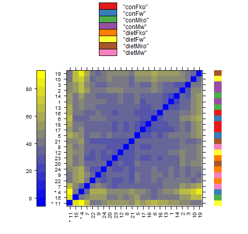

Heatmap de distancias entre los arrays realizado por arrayQualityMetrics

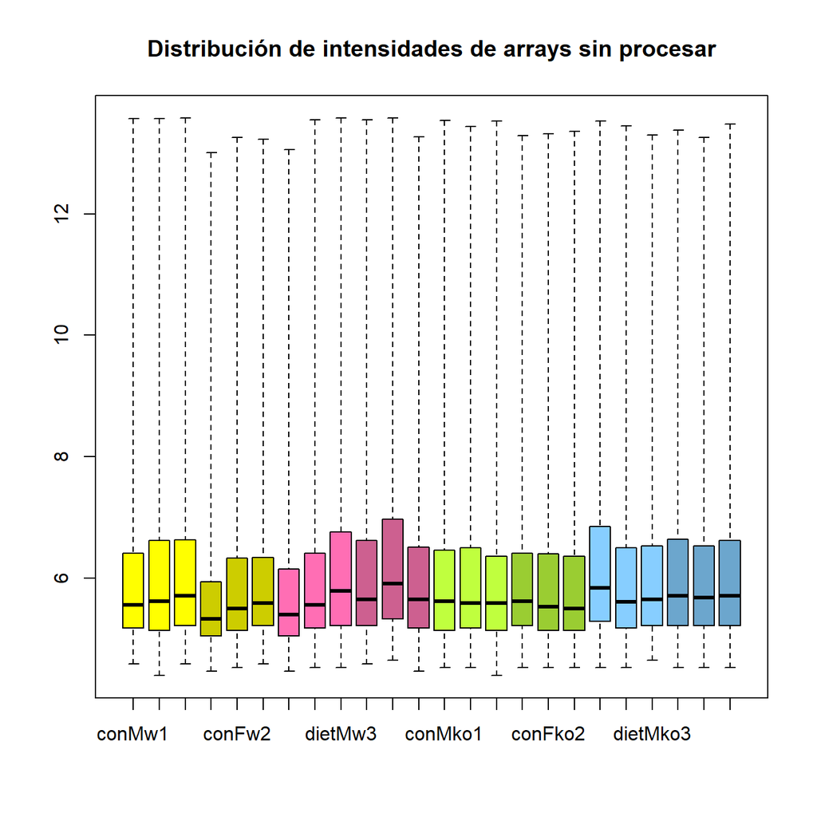

Boxplot de distribución intensidades de arrays

```r
> boxplot(EsetRaw, which = "all", col = c(rep("yellow1", 3), rep("yellow3",
+     3), rep("hotpink1", 3), rep("hotpink3", 3), rep("olivedrab1",
+     3), rep("olivedrab3", 3), rep("skyblue1", 3), rep("skyblue3",
+     3)), main = "Distribución de intensidades de arrays sin procesar")
```

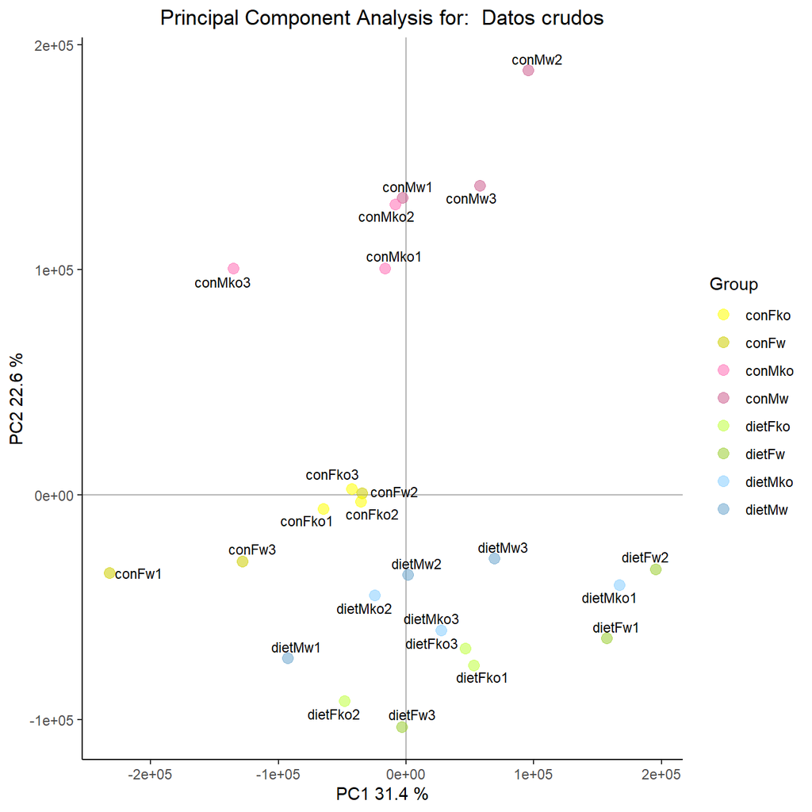

Visualización de los dos primeros componentes principales en datos crudos

## 3.3 Normalización

Realizamos la normalización de los datos mediante el método Robust Miltuchip Analysis:

```r
> eset_rma <- rma(EsetRaw)
```

```
Background correcting
Normalizing
Calculating Expression
```

## 3.4 Control de calidad de los datos normalizados

```r
> library(arrayQualityMetrics)
> arrayQualityMetrics(eset_rma, outdir = file.path("./results",
+     "QM_Norm"), force = TRUE, intgroup = "X.Grupo.")
```

Los resultados del análisis de calidad se encuentran en el directorio “QM_Norm”, en el archivo “index.html”.

Realizamos también un boxplot y un análisis de componentes principales de los datos normalizados:

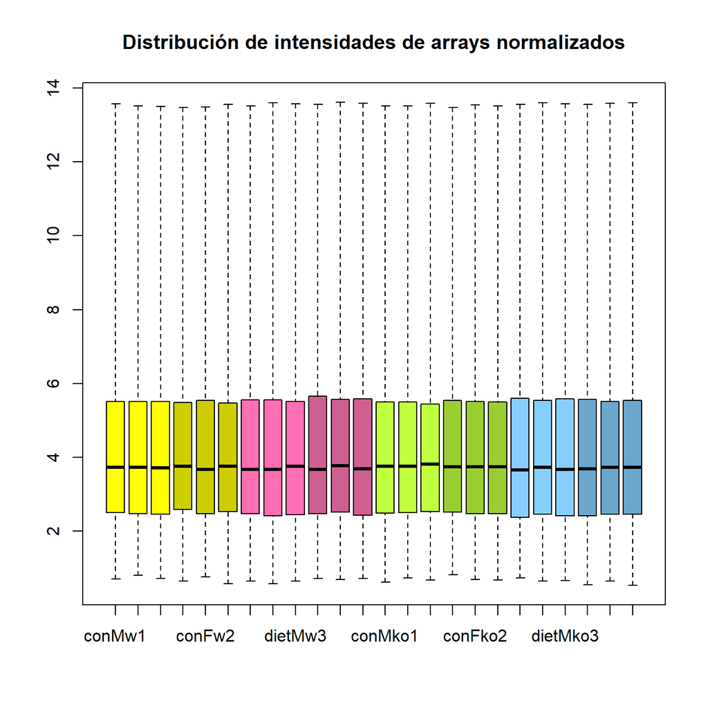

Boxplot de distribución intensidades de arrays normalizadas

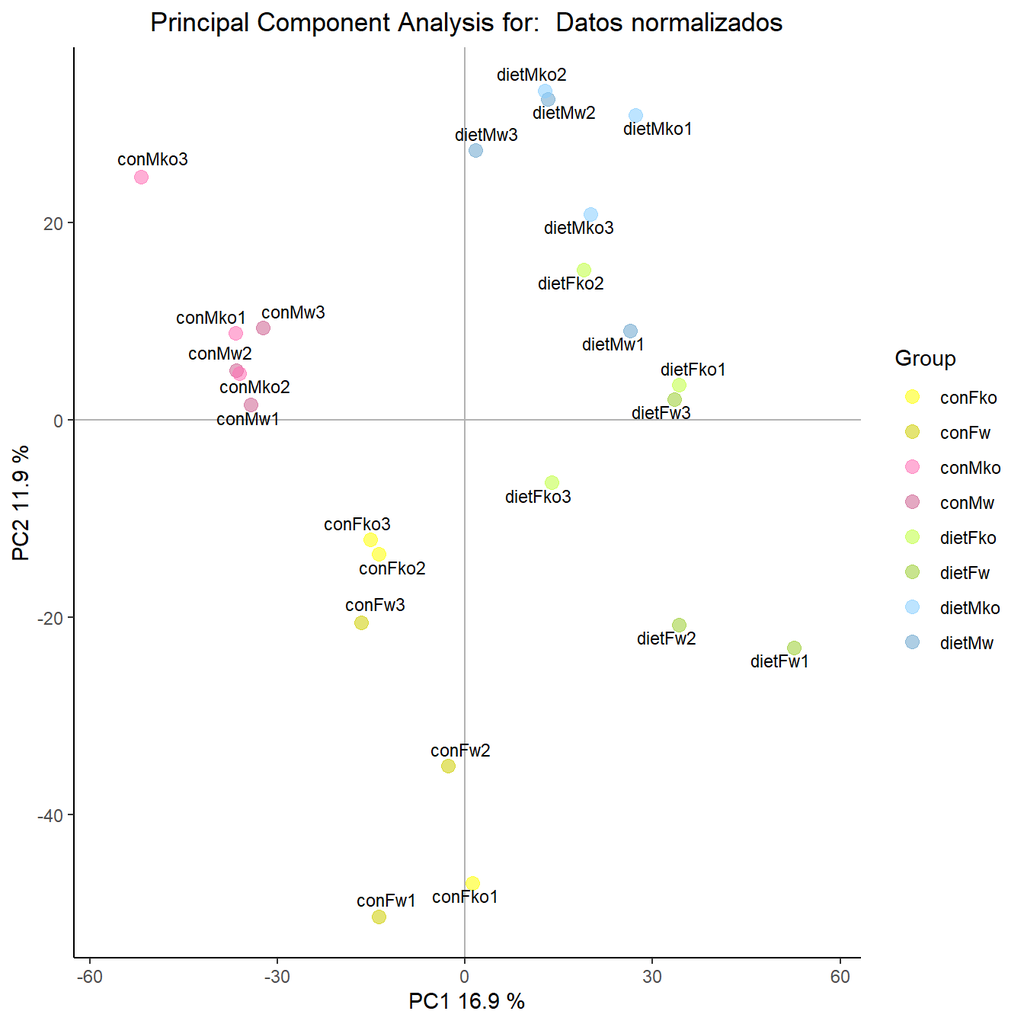

Visualización de los dos primeros componentes principales en datos normalizados

### 3.4.1 Identificación de lotes

Comprobamos la fecha en que las muestras fueron procesadas:

```r
> library(affyio)
>
> get.celfile.dates(fileList)
```

```
 [1] "2018-05-23" "2018-05-23" "2018-05-23" "2018-05-23" "2018-05-23"
 [6] "2018-05-23" "2018-05-23" "2018-05-23" "2018-05-23" "2018-05-23"
[11] "2018-05-23" "2018-05-23" "2018-05-23" "2018-05-23" "2018-05-23"
[16] "2018-05-23" "2018-05-23" "2018-05-23" "2018-05-23" "2018-05-23"
[21] "2018-05-23" "2018-05-23" "2018-05-23" "2018-05-23"
```

En nuestro caso todas las muestras se procesaron el mismo día, así que no tenemos que tener en cuenta este factor.

Hacemos un Principal variation component analysis (PVCA):

```r
> library(pvca)
> pData(eset_rma) <- targets_csv
>
> pct_thershold <- 0.6
> batch.factors <- c("Genotipo", "Dieta", "Genero")
>
> pvcaObj <- pvcaBatchAssess(eset_rma, batch.factors, pct_thershold)
```

## 3.5 Filtraje no específico (opcional)

Detectamos los genes más variables mediante una representación gráfica de la desviación standard de todos los genes ordenada de menor a mayor:

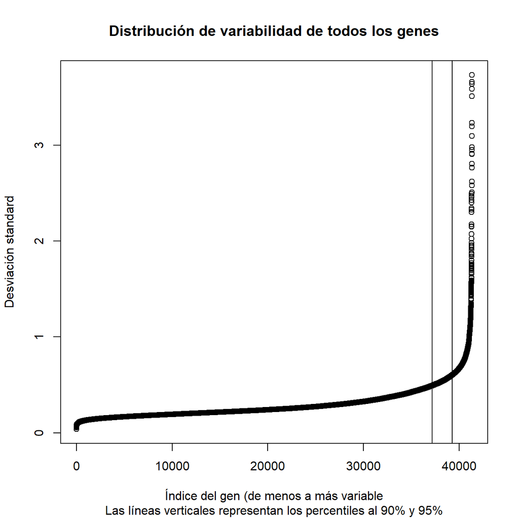

A continuación, realizamos un filtrado de los genes menos variables:

```r
> library(genefilter)
> library(mogene21sttranscriptcluster.db)
> annotation(eset_rma) <- "mogene21sttranscriptcluster.db"
> filtered <- nsFilter(eset_rma, require.entrez = TRUE, remove.dupEntrez = TRUE,
+     var.filter = TRUE, var.func = IQR, var.cutoff = 0.75, filterByQuantile = TRUE,
+     feature.exclude = "^AFFX")
```

```r
> print(filtered$filter.log)
```

```
$numDupsRemoved
[1] 671

$numLowVar
[1] 17973

$numRemoved.ENTREZID
[1] 16710
```

```r
> eset_filtered <- filtered$eset
```

Tras el filtrado nos quedan 5991 genes. Los tenemos ordenados en la variable *eset_filtered*.

Los datos normalizados y los filtrados están guardados en el directorio “results”.

## 3.6 Selección de genes diferencialmente expresados

Primero creamos la matriz de diseño del experimento:

```r
> library(limma)
> pDat_eFiltered <- pData(eset_filtered)
> designMat <- model.matrix(~0 + Grupo, pDat_eFiltered)
> Grupos <- as.vector(levels(pDat_eFiltered$Grupo))
> colnames(designMat) <- Grupos
> print(designMat)
```

```
   conFko conFw conMko conMw dietFko dietFw dietMko dietMw
1       0     0      0     1       0      0       0      0
2       0     0      0     1       0      0       0      0
3       0     0      0     1       0      0       0      0
4       0     1      0     0       0      0       0      0
5       0     1      0     0       0      0       0      0
6       0     1      0     0       0      0       0      0
7       0     0      0     0       0      0       0      1
8       0     0      0     0       0      0       0      1
9       0     0      0     0       0      0       0      1
10      0     0      0     0       0      1       0      0
11      0     0      0     0       0      1       0      0
12      0     0      0     0       0      1       0      0
13      0     0      1     0       0      0       0      0
14      0     0      1     0       0      0       0      0
15      0     0      1     0       0      0       0      0
16      1     0      0     0       0      0       0      0
17      1     0      0     0       0      0       0      0
18      1     0      0     0       0      0       0      0
19      0     0      0     0       0      0       1      0
20      0     0      0     0       0      0       1      0
21      0     0      0     0       0      0       1      0
22      0     0      0     0       1      0       0      0
23      0     0      0     0       1      0       0      0
24      0     0      0     0       1      0       0      0
attr(,"assign")
[1] 1 1 1 1 1 1 1 1
attr(,"contrasts")
attr(,"contrasts")$Grupo
[1] "contr.treatment"
```

Seguimos con el diseño de la matriz de contrastes: necesitaremos hacer 9 contrastes en este estudio:

- El primero será un contraste entre los datos de ratones macho wt, con dieta control vs MCD, es decir, los ratones sanos vs lo que presentan enfermedad hepática (NAFLD). Lo llamamos “CONvsDIET.Mwt”.
- Comparamos también entre géneros (Macho vs Hembra), necesitaremos 4 contrastes para ello:
- Dieta control, genotipo wt: “MvsF.con_wt”
- Dieta control, genotipo ko: “MvsF.con_ko”
- Dieta MCD, genotipo wt: “MvsF.diet_wt”
- Dieta MCD, genotipo ko: “MvsF.diet_ko”
- Hacemos comparaciones entre genotipos (wt vs ko), requerimos 4 comparaciones:
- Dieta control, macho: “KOvsWT.con_M”
- Dieta MCD, macho: “KOvsWT.diet_M”
- Dieta control, hembra: “KOvsWT.con_F”
- Dieta MCD, hembra: “KOvsWT.diet_F”

```
         Contrasts
Levels    CONvsDIET.Mwt MvsF.con_wt MvsF.con_ko MvsF.diet_wt MvsF.diet_ko
  conFko              0           0          -1            0            0
  conFw               0          -1           0            0            0
  conMko              0           0           1            0            0
  conMw              -1           1           0            0            0
  dietFko             0           0           0            0           -1
  dietFw              0           0           0           -1            0
  dietMko             0           0           0            0            1
  dietMw              1           0           0            1            0
         Contrasts
Levels    KOvsWT.con_M KOvsWT.diet_M KOvsWT.con_F KOvsWT.diet_F
  conFko             0             0            1             0
  conFw              0             0           -1             0
  conMko             1             0            0             0
  conMw             -1             0            0             0
  dietFko            0             0            0             1
  dietFw             0             0            0            -1
  dietMko            0             1            0             0
  dietMw             0            -1            0             0
```

Con estas matrices diseñadas, hacemos la estimación del modelo:

```r
> library(limma)
> fit <- lmFit(eset_rma, designMat)
> fit.main <- contrasts.fit(fit, cont.matrix)
> fit.main <- eBayes(fit.main)
> class(fit.main)
```

```
[1] "MArrayLM"
attr(,"package")
[1] "limma"
```

Obtenemos las tablas de la lista de genes ordenados de más a menos diferencialmente expresados en cada una de las 9 comparaciones.

Muestro el código y las primeras líneas del resultado para la primera comparación

```r
> topTab_CONvsDIET.Mwt <- topTable(fit.main, number = nrow(fit.main),
+     coef = "CONvsDIET.Mwt", adjust = "fdr")
> head(topTab_CONvsDIET.Mwt)
```

|  | logFC | AveExpr | t | P.Value | adj.P.Val | B |
| --- | --- | --- | --- | --- | --- | --- |
| 17475385 | 8.024836 | 9.306083 | 22.36793 | 0 | 0e+00 | 22.11327 |
| 17229059 | 8.263973 | 9.376584 | 18.75296 | 0 | 0e+00 | 19.99011 |
| 17220417 | -2.230688 | 5.080070 | -13.78268 | 0 | 1e-07 | 15.77545 |
| 17475399 | 3.675900 | 10.294242 | 13.52714 | 0 | 2e-07 | 15.50454 |
| 17309832 | -2.590220 | 7.562732 | -12.98011 | 0 | 3e-07 | 14.90304 |
| 17449417 | 6.091941 | 6.861568 | 12.71824 | 0 | 3e-07 | 14.60429 |

## 3.7 Anotación de los resultados

Para la anotación de los resultados utilizaremos una función específicamente diseñada que aplicaremos a las 9 tablas de expresión de genes. Guardaremos las tablas de genes anotados en documentos .csv en el fichero “results”

```r
> annotatedTopTable <- function(topTab, anotPackage) {
+     topTab <- cbind(PROBEID = rownames(topTab), topTab)
+     myProbes <- rownames(topTab)
+     thePackage <- eval(parse(text = anotPackage))
+     geneAnots <- select(thePackage, myProbes, c("SYMBOL", "ENTREZID",
+         "GENENAME"))
+     annotatedTopTab <- merge(x = geneAnots, y = topTab, by.x = "PROBEID",
+         by.y = "PROBEID")
+     return(annotatedTopTab)
+ }
```

## 3.8 Comparación entre distintas comparaciones

Visualizamos los datos de la comparación entre dieta control y dieta MCD en un **Volcano plot**.

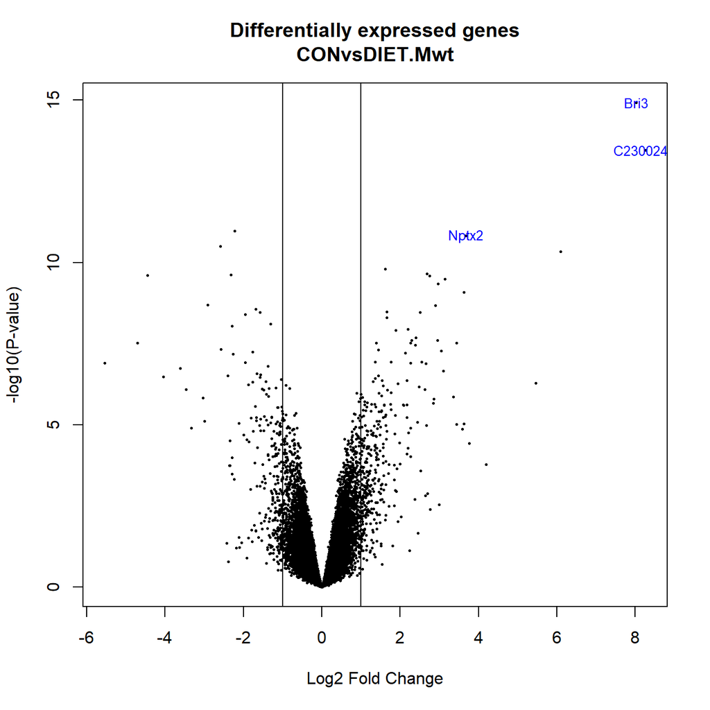

Generamos los volcano plots de todas las comparaciones para analizarlos en el apartado de resultados.

Los Volcano plots de todas las comparaciones se encuentran un documento pdf llamado “Volcanos.pdf” en el fichero “figures”.

### 3.8.1 Comparaciones múltiples

Realizamos un test de comparaciones múltiples para saber qué genes se encuentran regulados:

```r
> library(limma)
> decide <- decideTests(fit.main, method = "separate", adjust.method = "fdr",
+     p.value = 0.1, lfc = 1)
```

```r
> sum.decide.rows <- apply(abs(decide), 1, sum)
> decide.selected <- decide[sum.decide.rows != 0, ]
> print(summary(decide))
```

```
       CONvsDIET.Mwt MvsF.con_wt MvsF.con_ko MvsF.diet_wt MvsF.diet_ko
Down             144         115         133           92           26
NotSig         40948       41111       41135        41228        41300
Up               253         119          77           25           19
       KOvsWT.con_M KOvsWT.diet_M KOvsWT.con_F KOvsWT.diet_F
Down              0             0            0             8
NotSig        41344         41345        41345         41337
Up                1             0            0             0
```

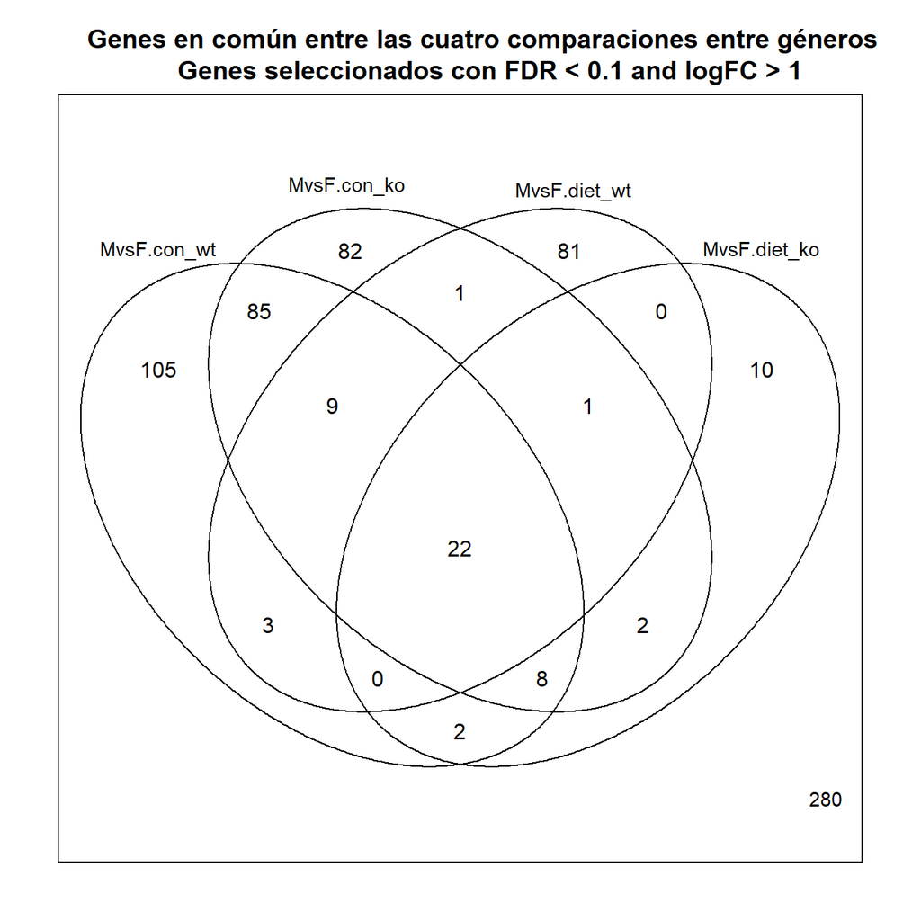

Diagrama de Venn de los genes en las comparaciones de género

```r
> vennDiagram(decide.selected[, 2:5], cex = 0.9)
> title("Genes en común entre las cuatro comparaciones entre géneros \n Genes seleccionados con FDR < 0.1 and logFC > 1")
```

Generamos un heatmap de los datos de expresión de los genes regulados según las comparaciones múltiples en cada muestra para detectar patrones de sobreexpresión o infraexpresión según las condiciones experimentales.

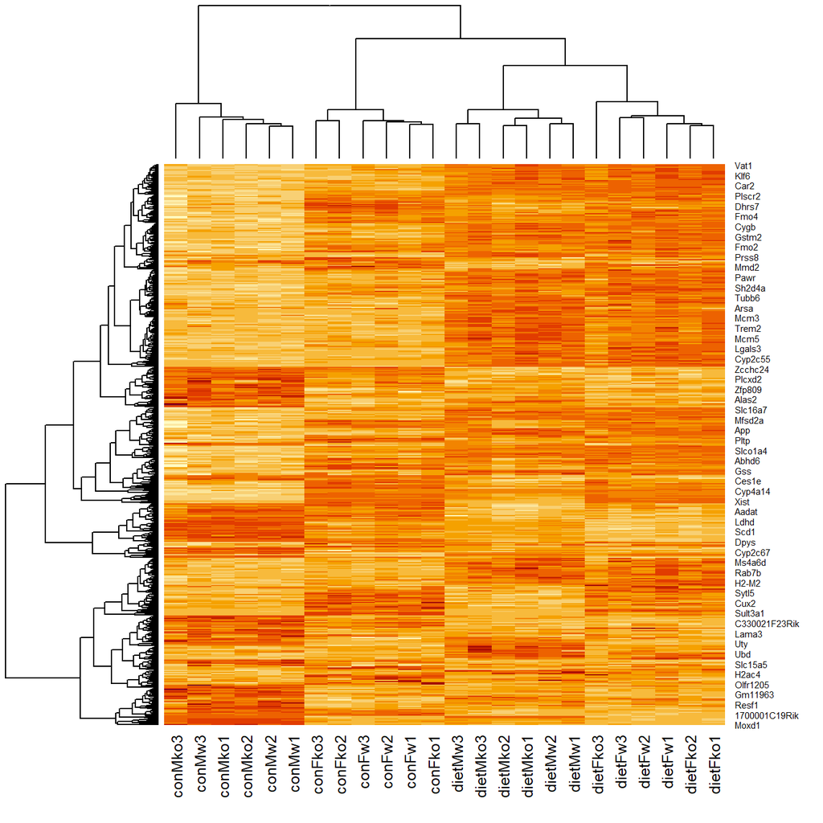

Heatmap de los datos de expresión agrupados por similitud

## 3.9 Análisis de significación biológica(“Gene Enrichment Analysis”)

Realizamos el análisis de significación biológica con el paquete “clusterProfiler”, descargando el archivo .gmt que contiene la información del organismo “Mus musculus”. (Yu, n.d.)

```r
> library(magrittr)
> library(clusterProfiler)
> library(rWikiPathways)
>
> wpgmt <- rWikiPathways::downloadPathwayArchive(organism = "Mus musculus",
+     format = "gmt")
> wp2gene <- clusterProfiler::read.gmt(wpgmt)
> wp2gene <- wp2gene %>% tidyr::separate(ont, c("name", "version",
+     "wpid", "org"), "%")
> wpid2gene <- wp2gene %>% dplyr::select(wpid, gene)  #TERM2GENE
> wpid2name <- wp2gene %>% dplyr::select(wpid, name)  #TERM2NAME
>
>
> E_CONvsDIET.Mw <- enricher(Genes_CONvsDIET.Mw, TERM2GENE = wpid2gene,
+     TERM2NAME = wpid2name)
```

Con una función específica creamos gráficos para poder visualizar los datos resultantes del enrichment analysis:

```r
> library(enrichplot)
>
> generatePlots <- function(enriched, comparacion) {
+     write.csv(as.data.frame(enriched), file = paste0("./results/",
+         "Enriched.", comparacion, ".csv"), row.names = FALSE)
+
+     png(filename = paste0("./results/", "Enriched.", comparacion,
+         ".png"))
+     print(barplot(enriched, showCategory = 15, font.size = 8,
+         title = paste0("Enrichment_Analysis_", comparacion, ". Barplot")))
+     dev.off()
+
+     png(filename = paste0("./results/", "Enrichment_cnetplot.",
+         comparacion, ".png"))
+     print(cnetplot(enriched, categorySize = "geneNum", schowCategory = 15,
+         vertex.label.cex = 0.75))
+     dev.off()
+ }
```

# 4 Resultados

En el análisis que hicimos previo al filtraje de los genes poco expresados, obtuvimos el siguiente barplot que nos especificaba en qué cantidad influía cada variable en la variabilidad de los datos de expresión de los genes:

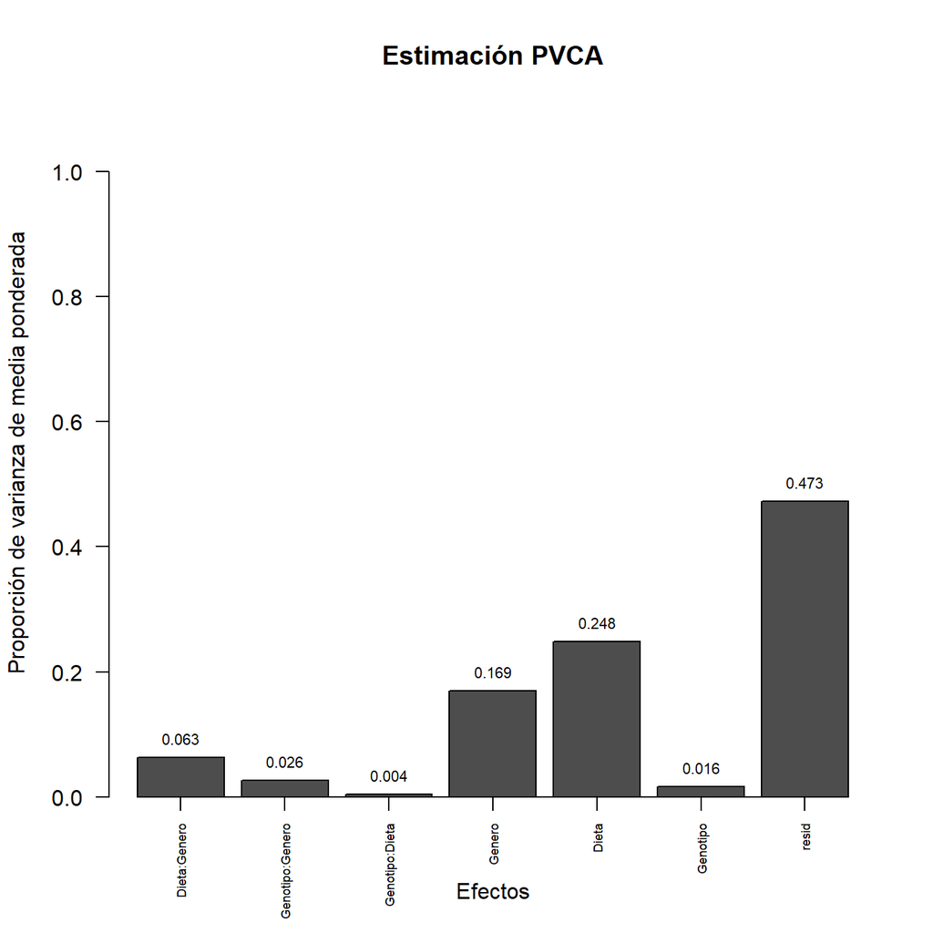

Barplot del análisis de Principal Varianci Component (PVCA)

En este plot ya podemos ver que el genotipo apenas influye en la regulación de la expresión génica, siendo la principal fuente de variación la dieta y la segunda el género.

Al observar los volcano plots de las comparaciones entre géneros vemos que son bastante similares, lo que nos lleva a confirmar que la variable género tiene mucha influencia en la regulación de los genes.

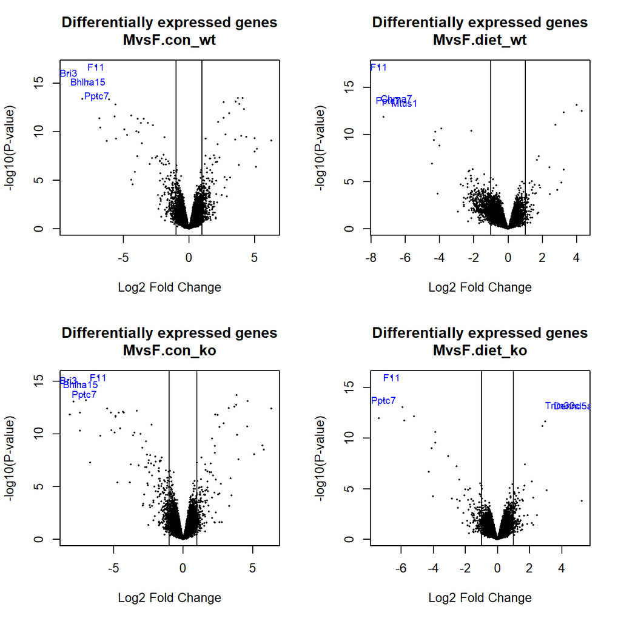

Volcano plots de las 4 comparaciones entre géneros

Sin embargo, al comparar los volcano plots de las comparaciones entre genotipos vemos que los puntos se distribuyen mucho más abajo en la gráfica en comparación con los volcano plots de las comparaciones entre género, esto nos confirma que los resultados de regulación de expresión obtenidos de estas comparaciones no serán muy significativos.

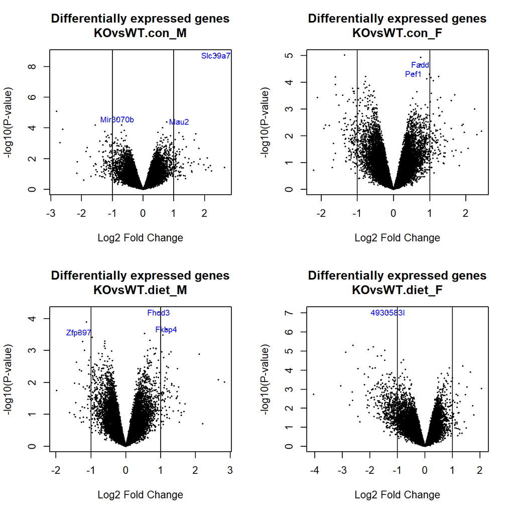

Volcano plots de las 4 comparaciones entre genotipos

Lo podemos confirmar definitivamente al hacer la comparación entre comparaciones, donde la tabla ya nos indica que en la mayoría de comparaciones entre genotipos no hay genes cuya expresión cambie significativamente.

```r
> print(summary(decide))
```

```
       CONvsDIET.Mwt MvsF.con_wt MvsF.con_ko MvsF.diet_wt MvsF.diet_ko
Down             144         115         133           92           26
NotSig         40948       41111       41135        41228        41300
Up               253         119          77           25           19
       KOvsWT.con_M KOvsWT.diet_M KOvsWT.con_F KOvsWT.diet_F
Down              0             0            0             8
NotSig        41344         41345        41345         41337
Up                1             0            0             0
```

Tan sólo hay un gen sobre-regulado en la comparación de ratones macho con dieta control, relacionado con el citocromo p-450, una proteína involucrada en varios procesos metabólicos. En la comparación de genotipo de ratones hembra sometidos a dieta hay 8 genes infra-regulados, pero no se ha encontrado información biológica al respecto en las bases de datos.

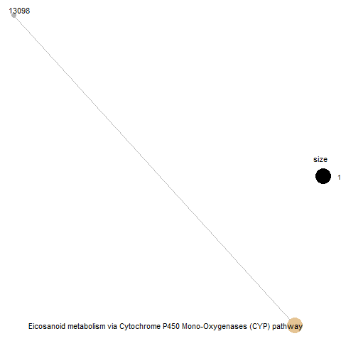

Al analizar los barplots del Enrichment analysis de las comparaciones entre géneros de los ratones con dieta control vemos que los genes pertenecen a las mismas rutas biológicas.

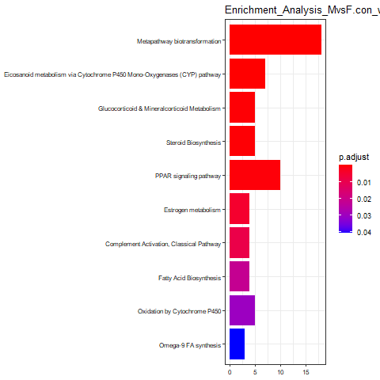

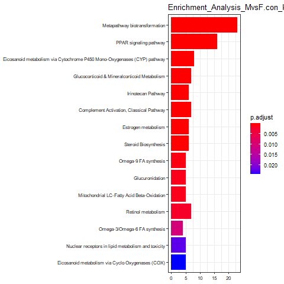

El cambio es notable cuando se compara con los ratones de genotipo normal sometidos a dieta MCD. Claramente la enfermedad provocada por la dieta altera la expresión génica:

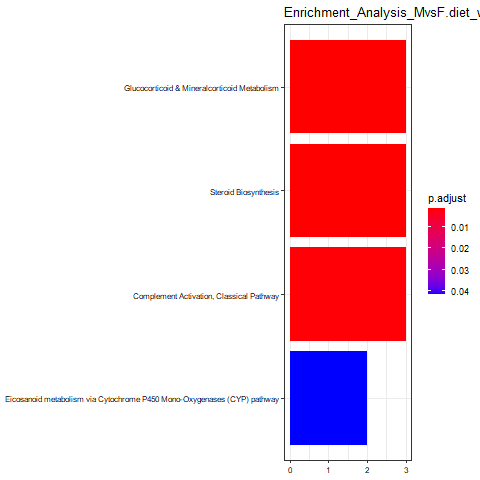

El número de genes significativament regulados se redice ligeramente en los ratones con genotipo ko y dieta MCD:

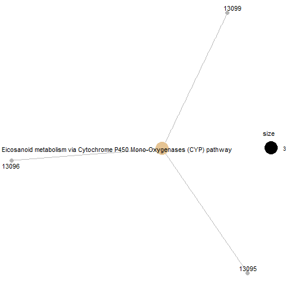

Sin embargo, la variable que más influye en la variación de expresión génica es la dieta MCD, que provoca la enfermedad NAFLD en los ratones. En ratones macho con dieta control, regula un total de 397 genes.

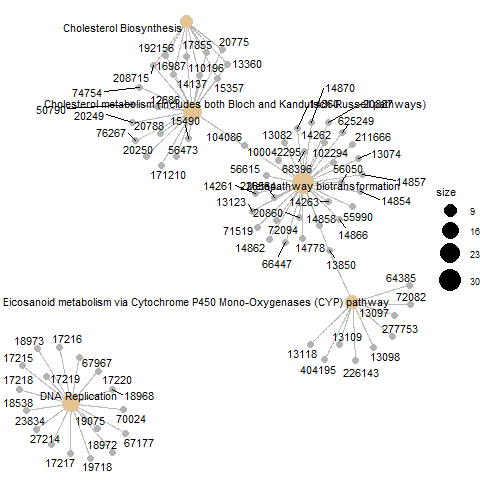

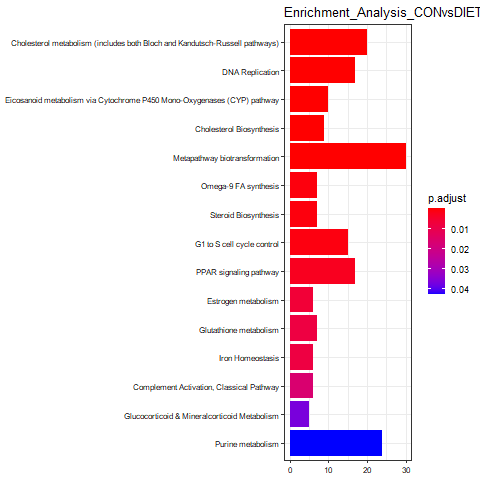

# 5 Discusión

# 6 Apéndice

En la siguiente URL se encuentra el repositorio de github con todos los archivos necesarios para reproducir el estudio y los archivos de resultados: https://github.com/riorval/ADO_PEC1.git*

# Bibliografía

Han, Mei, Weronika Piorońska, Sai Wang, Zeribe Chike Nwosu, Carsten Sticht, Shanshan Wang, Yan Gao, Matthias Philip Ebert, Steven Dooley, and Christoph Meyer. 2020. “Hepatocyte Caveolin-1 Modulates Metabolic Gene Profiles and Functions in Non-Alcoholic Fatty Liver Disease.” *Cell Death & Disease* 11 (2): 104. doi:10.1038/s41419-020-2295-5.

Yu, Guangchuang. n.d. “ClusterProfiler: Universal Enrichment Tool for Functional and Comparative Study.” *Chapter 3 Universal Enrichment Analysis*. https://yulab-smu.github.io/clusterProfiler-book/chapter3.html.